# WEEK 6: Analysis of longitudinal data

### Linear Mixed Effects Models using using the BPRSL data

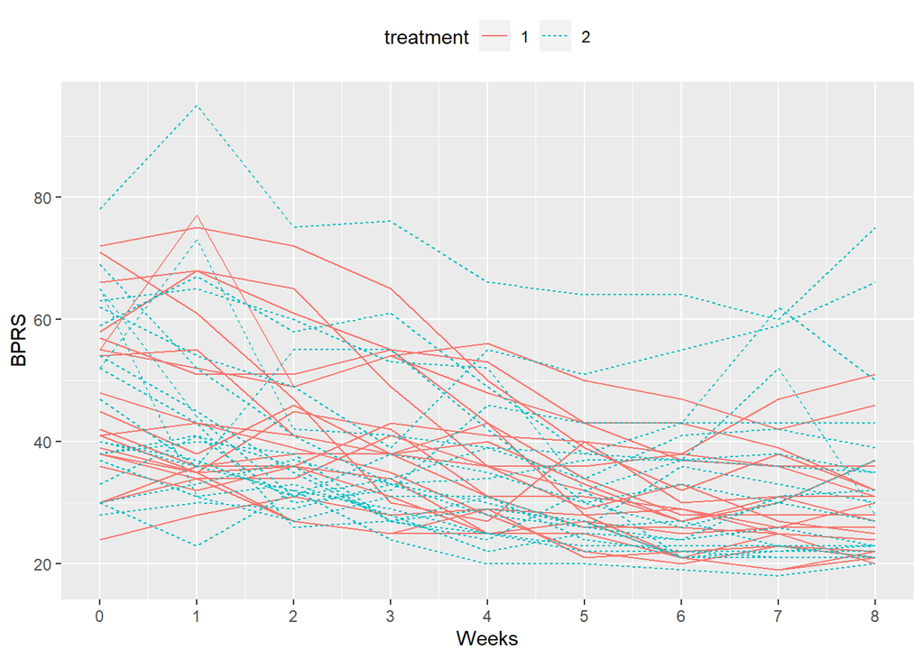

```r
# Plot the BPRSL data:
ggplot(BPRSL, aes(x = week, y = bprs, group = subject)) +
  geom_line(aes(linetype = treatment, color = treatment)) +
  scale_x_continuous(name = "Weeks", breaks = seq(0, 8, 1)) +
  scale_y_continuous(name = "BPRS", breaks = seq(0, 100, 20)) +
  theme(legend.position = "top")
```

**Figure 5.** Plot of BPRS indexes against time. Individuals having different treatments are illustrated by different line types and colors.

```r
# Create a regression model BPRS_reg and print out the model summary:
BPRS_reg <- lm(bprs ~ week + treatment, data = BPRSL)
summary(BPRS_reg)
```

```
##
## Call:
## lm(formula = bprs ~ week + treatment, data = BPRSL)
##
## Residuals:
##     Min      1Q  Median      3Q     Max
## -22.454  -8.965  -3.196   7.002  50.244
##
## Coefficients:
##             Estimate Std. Error t value Pr(>|t|)
## (Intercept)  46.4539     1.3670  33.982   <2e-16 ***
## week         -2.2704     0.2524  -8.995   <2e-16 ***
## treatment2    0.5722     1.3034   0.439    0.661
## ---
## Signif. codes:  0 '***' 0.001 '**' 0.01 '*' 0.05 '.' 0.1 ' ' 1
##
## Residual standard error: 12.37 on 357 degrees of freedom
## Multiple R-squared:  0.1851, Adjusted R-squared:  0.1806
## F-statistic: 40.55 on 2 and 357 DF,  p-value: < 2.2e-16
```

**Table 2.** The summary of simple linear regression model, where BPRS is modeled using time (week) and dummy variable of treatment. According to this print, treatment would not be significantly affecting to BPRS index value. **But remember that the use of linear regression assumes that all the measurements were independent, which is not true here due to the longitudinal character of the data.**

```r
# Create a random intercept model and print out the model summary:
BPRS_ref <- lmer(bprs ~ week + treatment + (1 | subject), data = BPRSL, REML = FALSE)
summary(BPRS_ref)
```

```
## Linear mixed model fit by maximum likelihood  ['lmerMod']
## Formula: bprs ~ week + treatment + (1 | subject)
##    Data: BPRSL
##
##      AIC      BIC   logLik deviance df.resid
##   2582.9   2602.3  -1286.5   2572.9      355
##
## Scaled residuals:
##      Min       1Q   Median       3Q      Max
## -2.27506 -0.59909 -0.06104  0.44226  3.15835
##
## Random effects:
##  Groups   Name        Variance Std.Dev.
##  subject  (Intercept) 97.39    9.869
##  Residual             54.23    7.364
## Number of obs: 360, groups:  subject, 40
##
## Fixed effects:
##             Estimate Std. Error t value
## (Intercept)  46.4539     2.3521  19.750
## week         -2.2704     0.1503 -15.104
## treatment2    0.5722     3.2159   0.178
##
## Correlation of Fixed Effects:
##            (Intr) week
## week       -0.256
## treatment2 -0.684  0.000
```

```r
# Create a random intercept and random slope model, and print out the summary:
BPRS_ref1 <- lmer(bprs ~ week + treatment + (week | subject), data = BPRSL, REML = FALSE)
summary(BPRS_ref1)
```

```
## Linear mixed model fit by maximum likelihood  ['lmerMod']
## Formula: bprs ~ week + treatment + (week | subject)
##    Data: BPRSL
##
##      AIC      BIC   logLik deviance df.resid
##   2523.2   2550.4  -1254.6   2509.2      353
##
## Scaled residuals:
##     Min      1Q  Median      3Q     Max
## -2.4655 -0.5150 -0.0920  0.4347  3.7353
##
## Random effects:
##  Groups   Name        Variance Std.Dev. Corr
##  subject  (Intercept) 167.827  12.955
##           week          2.331   1.527   -0.67
##  Residual              36.747   6.062
## Number of obs: 360, groups:  subject, 40
##
## Fixed effects:
##             Estimate Std. Error t value
## (Intercept)  45.9830     2.6470  17.372
## week         -2.2704     0.2713  -8.370
## treatment2    1.5139     3.1392   0.482
##
## Correlation of Fixed Effects:
##            (Intr) week
## week       -0.545
## treatment2 -0.593  0.000
```

**Table 4.** The summary of *random intercept and random slope model* to the BPRS data. The residuals are a bit lower than corresponding results in the previous table.

```r
# Perform an ANOVA test on the two models:
anova(BPRS_ref1, BPRS_ref)
```

```
## Data: BPRSL
## Models:
## BPRS_ref: bprs ~ week + treatment + (1 | subject)
## BPRS_ref1: bprs ~ week + treatment + (week | subject)
##           npar    AIC    BIC  logLik deviance  Chisq Df Pr(>Chisq)
## BPRS_ref     5 2582.9 2602.3 -1286.5   2572.9
## BPRS_ref1    7 2523.2 2550.4 -1254.6   2509.2 63.663  2  1.499e-14 ***
## ---
## Signif. codes:  0 '***' 0.001 '**' 0.01 '*' 0.05 '.' 0.1 ' ' 1
```

```r
# Create a random intercept and random slope model with the interaction:
BPRS_ref2 <- lmer(bprs ~ week + treatment + (week | subject) + (week * treatment), data = BPRSL, REML = FALSE)
summary(BPRS_ref2)
```

```
## Linear mixed model fit by maximum likelihood  ['lmerMod']
## Formula: bprs ~ week + treatment + (week | subject) + (week * treatment)
##    Data: BPRSL
##
##      AIC      BIC   logLik deviance df.resid
##   2523.5   2554.5  -1253.7   2507.5      352
##
## Scaled residuals:
##     Min      1Q  Median      3Q     Max
## -2.4747 -0.5256 -0.0866  0.4435  3.7884
##
## Random effects:
##  Groups   Name        Variance Std.Dev. Corr
##  subject  (Intercept) 164.204  12.814
##           week          2.203   1.484   -0.66
##  Residual              36.748   6.062
## Number of obs: 360, groups:  subject, 40
##
## Fixed effects:
##                 Estimate Std. Error t value
## (Intercept)      47.8856     2.9840  16.047
## week             -2.6283     0.3752  -7.006
## treatment2       -2.2911     4.2200  -0.543
## week:treatment2   0.7158     0.5306   1.349
##
## Correlation of Fixed Effects:
##             (Intr) week   trtmn2
## week        -0.668
## treatment2  -0.707  0.473
## wek:trtmnt2  0.473 -0.707 -0.668
```

**Table 6.** Summary of *a random intercept and random slope model with the interaction of week and treatment*

```r
# Perform an ANOVA test on the two models:
anova(BPRS_ref2, BPRS_ref1)
```

```
## Data: BPRSL
## Models:
## BPRS_ref1: bprs ~ week + treatment + (week | subject)
## BPRS_ref2: bprs ~ week + treatment + (week | subject) + (week * treatment)
##           npar    AIC    BIC  logLik deviance Chisq Df Pr(>Chisq)
## BPRS_ref1    7 2523.2 2550.4 -1254.6   2509.2
## BPRS_ref2    8 2523.5 2554.6 -1253.7   2507.5  1.78  1     0.1821
```

**Table 7.** ANOVA test reveals that the interaction of week and treatment does not improve model fit in this BPRS data.

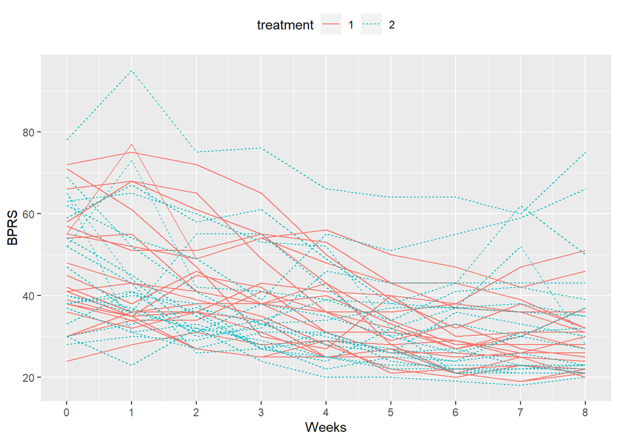

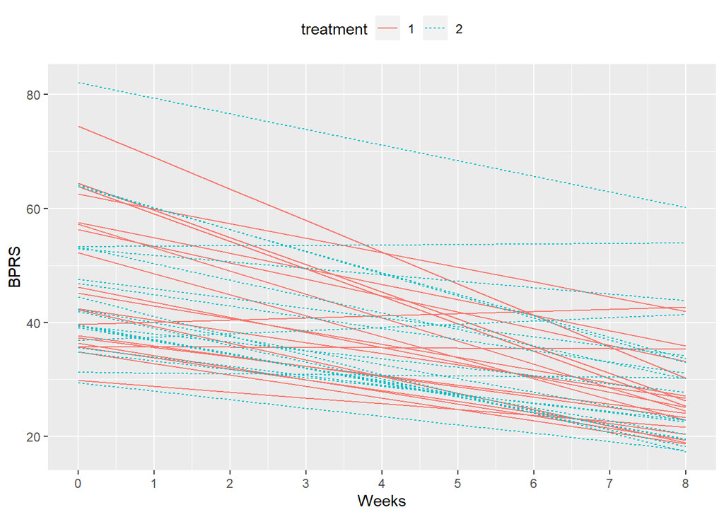

```r
par(mar = c(4, 6, .1, .1))

# Draw the plot of BPRSL with the observed Weight values:
ggplot(BPRSL, aes(x = week, y = bprs, group = subject)) +
  geom_line(aes(linetype = treatment, color = treatment)) +
  scale_x_continuous(name = "Weeks", breaks = seq(0, 8, 1)) +
  scale_y_continuous(name = "BPRS", breaks = seq(0, 100, 20)) +
  theme(legend.position = "top")

# Create a vector of the fitted values (ref1):
Fitted <- fitted(BPRS_ref1)

# Create a new column fitted to RATSL:
BPRSL <- mutate(BPRSL, fitted = Fitted)

# Draw the plot of BPRSL with the Fitted values of weight:
ggplot(BPRSL, aes(x = week, y = fitted, group = subject)) +
  geom_line(aes(linetype = treatment, color = treatment)) +
  scale_x_continuous(name = "Weeks", breaks = seq(0, 8, 1)) +
  scale_y_continuous(name = "BPRS", breaks = seq(0, 100, 20)) +
  theme(legend.position = "top")
```